# Assignment 4

Rudklao Raviyan

2023-10-11

We have data from a study of people with pre-diabetes, which followed them over the course of 10 months. At enrollment in the study, they fill out a survey about their eating habits; they then attend a clinic that makes relevant clinical measurements every month (these are their weight relative to their ideal weight, “relwt”, fasting glucose “glufast”, blood glucose response to a glucose tolerance test “glutest”, steady state plasma glucose response “steady”, and insulin response to a glucose tolerance test “insulin”). Each month’s data is in a separate file; it also includes basic patient information including their ID number, sex, and the clinic location they attended (“N” or “S”). We know some people have missed one or more appointments, but we would like to retain all people who attended at least 1 clinic appointment. A fairly large number of people filled out the survey but did not ulitmately attend any clinic appointments; we wish to discard these participants. The data is in the file “diabetes-data.zip”

# Question 1

*We know that at least one analysis we wish to perform requires all the data (10 time points plus the survey data) in a single wide format dataframe.*

## a:

*Briefly outline your strategy for this task. Do not write the code yet, but outline the functions and key arguments you will use. For purposes of this assignment, it is OK if you end up doing something slightly different.*

Upon investigating the file names, the files are being saved in the same pattern. I would create a vector containing file names. Then, I would generate a repeated pattern from T1 to T10 and concatenate it with ‘diabetes’ to generate the file names. After that, I would write a function to concatenate the file name to the path directory. Next, I would use lapply to join all the datasets together. Finally, I might use reshape/pivot functions to change the format to a wide format. The functions that might be used include paste(), read.csv(), lapply(), and some join functions.

## b:

*Write the code to execute this task, including comments to make it clear what you are doing. Then write out the resulting dataframe to a csv file.*

```r
# generate number 1 - 10
t_name <- seq(1,10)
# concateante T with the numbers
t_digit <- paste0("T", t_name)

# concatenate Tx with diabetes.csv
filenames <- paste0(t_digit, "diabetes.csv" )
getwd()
```

```
## [1] "D:/Documents/Uni_UoA/Stats 380/Assignments/Assignment 4"
```

```r
# paste the pathnames to the filenames
pathnames  <- paste0("diabetes-data-1/diabetes-data/", filenames)
# read the all the files
diabetes <- lapply(pathnames, read.csv)
#gsub/ grab info out


# create the rename function so it attach the time point to the header
renamecol <- function(df, suffix){
  colnames(df)[-1] <- paste(colnames(df)[-1], suffix, sep = "-")
  df
  }

# write the funciton that medge all datasets together
merge_DF <- function(x,y){
  merge(x, y, all = TRUE)
}

# rename the dataset before merging
diabetes_renamed <- mapply(renamecol, diabetes, t_digit, SIMPLIFY = FALSE)

# merge data set
merged_diabetes <- Reduce(merge_DF, diabetes_renamed)

# read survey data and merge using right join
survey <- read.csv('diabetes-data-1/diabetes-data/survey.csv')
all_diabetes <- right_join(x = survey, y = merged_diabetes, "id")

# create a new csv file
write.csv(all_diabetes, "A4_q1_all_diabetes.csv")
```

## c:

*Reflect on the strategy in part (a). Were you able to execute it as planned, or were changed needed? Briefly explain.* No, because I realized that we need to rename the columns before merging the data; otherwise, we would not know where the measurements come from at each time point. Hence, I need to rename and then merge the data. Also, the merge function can only take two datasets at a time, so I needed to write a function to merge the data in a vectorized computational way. Then, I joined it with a right join.

# Task 2:

*We now wish to perform some data checking tasks. We should have only one sex (“M” or “F”) and one clinic location (“N” or “S”) for each individual; we would like to check that this is true. We also know individuals are missing from some time points, so we would like to build a single ‘consensus’ vector that has the sex information for each patient ID, and a second vector with the location information.*

## a:

*Again, outline a strategy for this task including key functions and you will use.*

To check the data, we need to retrieve the “sex” columns from the main dataset. Then, we should examine the data by row, as each row represents an individual patient, using lapply() and unique(). After that, we should summarize the data to identify any mis-entered values by creating a table with lapply() and table(), and then correct them. Repeat the process for the “location” columns.

## b:

*Write code that identifies any idiosyncracies, including comments that explain how it works. If you have multiple sex or location vectors in your dataframe, replace them with a single vector for each variable.*

```r
# grap sex columns
gender_cols <- grep(pattern = "^sex", x = colnames(all_diabetes))

gender <- all_diabetes[gender_cols]

# check data, SEX-T4 seems to wrong
head(gender)
```

```
##   sex-T1 sex-T2 sex-T3 sex-T4 sex-T5 sex-T6 sex-T7 sex-T8 sex-T9 sex-T10
## 1      M      M      M      S      M      M      M      M      M       M
## 2      M      M      M      S      M      M      M      M      M       M
## 3      M      M      M      S      M      M      M      M      M       M
## 4      F      F      F      S      F      F      F      F      F       F
## 5      F      F      F      S      F      F      F      F   <NA>       F
## 6      M      M      M      N      M      M      M      M      M       M
```

```r
# rename columns, swap sex-T4 and locaiton-T4
colnames(all_diabetes)[which(colnames(all_diabetes) == "sex-T4")] = "change_to_location"
colnames(all_diabetes)[which(colnames(all_diabetes) == "location-T4")] = "change_to_sex"

colnames(all_diabetes)[which(colnames(all_diabetes) == "change_to_location")] = "location-T4"
colnames(all_diabetes)[which(colnames(all_diabetes) == "change_to_sex")] = "sex-T4"

# repeat and check the data again if the naming and the values are correct
gender_cols <- grep(pattern = "^sex", x = colnames(all_diabetes))
gender <- all_diabetes[gender_cols]
# check the data again
head(gender)
```

```
##   sex-T1 sex-T2 sex-T3 sex-T4 sex-T5 sex-T6 sex-T7 sex-T8 sex-T9 sex-T10
## 1      M      M      M      M      M      M      M      M      M       M
## 2      M      M      M      M      M      M      M      M      M       M
## 3      M      M      M      M      M      M      M      M      M       M
## 4      F      F      F      F      F      F      F      F      F       F
## 5      F      F      F      F      F      F      F      F   <NA>       F
## 6      M      M      M      M      M      M      M      M      M       M
```

```r
# grap unique values to each row
gender_check1 <- apply(X = gender, MARGIN = 1, FUN = unique, simplify = T)
#lapply length then unlist it, if the length is more than 1, there are more than 1 gender in the row
gender_check2 <- unlist(lapply(X = gender_check1, FUN = length))
#summary tab
gender_table <- tibble(gender_check2)
# unusual entry, more than 1 gender that is not NAs, check id
gender_id <- cbind(all_diabetes$id, gender)
gender_id[24,]
```

```
##    all_diabetes$id sex-T1 sex-T2 sex-T3 sex-T4 sex-T5 sex-T6 sex-T7 sex-T8
## 24             100      M      M      M      M   <NA>      M      F      M
##    sex-T9 sex-T10
## 24      M       M
```

```r
# create a frequency table to count the male gender
frequency_table <- apply(X = gender[,1:10] == "M", MARGIN = 1, FUN = sum, na.rm = TRUE)
frequency_table
```

```
##  [1] 10 10 10  0  0 10  9 10  0  9 10  0  9 10  0  9 10  0  0  0  0 10  9  8  9
## [26]  0  0  0 10  0 10 10 10  0 10  0
```

```r
# create a new vector, if the count of male is more than 7, then all the sex columns should be male, else, female
sex <- ifelse( frequency_table > 7, "M", "F")

# repeat for location
location_cols <- grep(pattern = "^location", x = colnames(all_diabetes))
# grab locaiton columns
location <- all_diabetes[location_cols]

# grap unique values to each row
location_check1 <- apply(X = location, MARGIN = 1, FUN = unique, simplify = T)
# check how many unique values in the row
location_check2 <- unlist(lapply(X = gender_check1, FUN = length))
location_table <- tibble(location_check2)
# unusual entry, more than 1 gender that is not NAs, check id
location_id <- cbind(all_diabetes$id, location)
location_id[25,]
```

```
##    all_diabetes$id location-T1 location-T2 location-T3 location-T4 location-T5
## 25             101           S           S           S           S          MS
##    location-T6 location-T7 location-T8 location-T9 location-T10
## 25           S           S           S           S            S
```

```r
# create the frequency table
frequency_table_location <- apply(X = location[,1:10] == "N", MARGIN = 1, FUN = sum, na.rm = TRUE)

# create the location vector with a single values
locations <- ifelse( frequency_table_location > 7, "N", "S")

# combine the sex and locations into the edited data set
all_diabetes_edited <- cbind(all_diabetes, sex, locations)

# remove gender-TX and location-TX columns
gender_cols_remove <- grep(pattern = "^sex-T", x = colnames(all_diabetes_edited))
all_diabetes_edited <- all_diabetes_edited[,-gender_cols_remove]
head(all_diabetes_edited)
```

```
##   id takeaways coffeepurch  mealprep wldiet relwt-T1 glufast-T1 glutest-T1
## 1 59         1           1 Sometimes      0     1.04         97        479
## 2 62         4           2    Always      0     1.00         91        447
## 3 63         1           1     Never      1     1.26        104        417
## 4 65         2           3     Never      0     1.13         85        470
## 5 66         1           0 Sometimes      1     1.04         88        433
## 6 71         2           3    Always      0     1.04         90        441
##   steady-T1 insulin-T1 location-T1 relwt-T2 glufast-T2 glutest-T2 steady-T2
## 1       144        122           S     1.00        110        536       140
## 2       256        244           S     1.04         89        428       164
## 3       195        194           S     1.18         96        449       252
## 4       151        257           S     1.18         88        468       104
## 5       129        167           S     1.06         90        424       119
## 6       339        270           N     1.08         89        425       345
##   insulin-T2 location-T2 relwt-T3 glufast-T3 glutest-T3 steady-T3 insulin-T3
```

[output cut: 55 more lines]

```r
# remove locations
location_cols_remove <- grep(pattern = "^location-T", x = colnames(all_diabetes_edited))
all_diabetes_edited <- all_diabetes_edited[,-location_cols_remove]
head(all_diabetes_edited)
```

```
##   id takeaways coffeepurch  mealprep wldiet relwt-T1 glufast-T1 glutest-T1
## 1 59         1           1 Sometimes      0     1.04         97        479
## 2 62         4           2    Always      0     1.00         91        447
## 3 63         1           1     Never      1     1.26        104        417
## 4 65         2           3     Never      0     1.13         85        470
## 5 66         1           0 Sometimes      1     1.04         88        433
## 6 71         2           3    Always      0     1.04         90        441
##   steady-T1 insulin-T1 relwt-T2 glufast-T2 glutest-T2 steady-T2 insulin-T2
## 1       144        122     1.00        110        536       140   147.4444
## 2       256        244     1.04         89        428       164   233.0000
## 3       195        194     1.18         96        449       252   199.3333
## 4       151        257     1.18         88        468       104   246.7778
## 5       129        167     1.06         90        424       119   154.6667
## 6       339        270     1.08         89        425       345   270.3333
##   relwt-T3 glufast-T3 glutest-T3 steady-T3 insulin-T3 relwt-T4 glufast-T4
```

[output cut: 41 more lines]

## c:

*Reflect on the strategy in part (a). Were you able to execute it as planned, or were changed needed? Briefly explain.*

In the T4 dataset, the “sex” and “location” columns were swapped, so I had to rename them. Initially, I used placeholder names before correcting them to the actual ‘sex-T4’ and ‘location-T4’. Additionally, when I employed the lapply function to check the unique values, it created a list within a list. Consequently, I had to collapse the list and inspect the columns with unusual values using the length function.

An unexpected issue arose when correcting values. One patient (patient id = 100) had two gender values in the “sex” column (both M and F), and another patient (patient id = 101) had their location entered as MS. To address this, I created a frequency table using ifelse() to help generate a single vector for “sex” and “location”. This was achieved by using the mode, where if there was a higher count for a particular gender or location, then I designated it as the single sex or location. For instance, if there were more ‘M’ values in the “sex” column than ‘NA’ or ‘F’ values, that patient was identified as Male.

# Question 3:

*Summarize the amount of missing data for each patient–in otherwords, how many patients have complete measurements? how many are missing 1 timepoint, how many missing 2, etc.*

```r
# create a function that summ all the amount of NA values
check_na <- function(x) {
  # total NAs missing
  sum_na = sum(is.na(x))
  # most of the patient who have NAs, they will miss all measurements which are 5 measurements in 1 time point so I divided by 5 so the missing NAs will become 1 time point.
  multiple_of_5 = ifelse(sum_na %% 5 == 0, sum_na / 5, sum_na)
}

# applied to the patients by row using the created check_na function
patients_check_na <- apply(X = all_diabetes_edited, MARGIN = 1, FUN = check_na, simplify = T)

# check data
rows_missing_values <- which(patients_check_na > 0)
head(all_diabetes_edited[rows_missing_values,])
```

```
##    id takeaways coffeepurch  mealprep wldiet relwt-T1 glufast-T1 glutest-T1
## 5  66         1           0 Sometimes      1     1.04         88        433
## 7  77         2           3 Sometimes      1     1.10         95        430
## 10 86         4           3 Sometimes      1     0.96        108        567
## 13 89         4           5     Never      0     1.16        100        474
## 16 92         0           2    Always      0     1.08        103        544
## 23 99         5           3 Sometimes      0       NA         NA         NA
##    steady-T1 insulin-T1 relwt-T2 glufast-T2 glutest-T2 steady-T2 insulin-T2
## 5        129        167     1.06         90        424       119   154.6667
## 7        218        177     1.02         96        409       200   162.8889
## 10       693        122     0.91        116        602       586   144.4444
## 13       649        271       NA         NA         NA        NA         NA
## 16       469        233     1.11        105        485       431   220.8889
## 23        NA         NA     1.11         92        503       543   200.4444
##    relwt-T3 glufast-T3 glutest-T3 steady-T3 insulin-T3 relwt-T4 glufast-T4
```

[output cut: 41 more lines]

```r
# number of time point missing,
table(patients_check_na)
```

```
## patients_check_na
##  0  1
## 28  8
```

From the table, there are 8 patients who missed 1 time point with 28 patients have no missing time point.

# Question 4:

*For each of the five clinical variables, make a boxplot for each timepoint, to check if there are any extreme observations. Summarize your conclusions.*

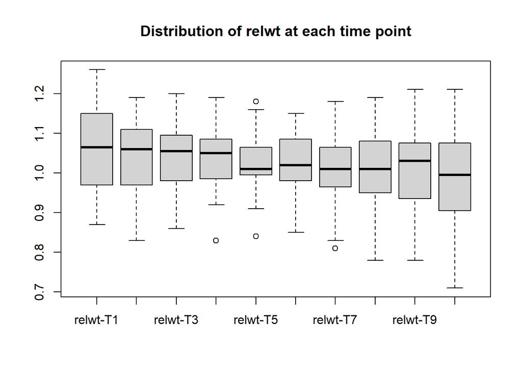

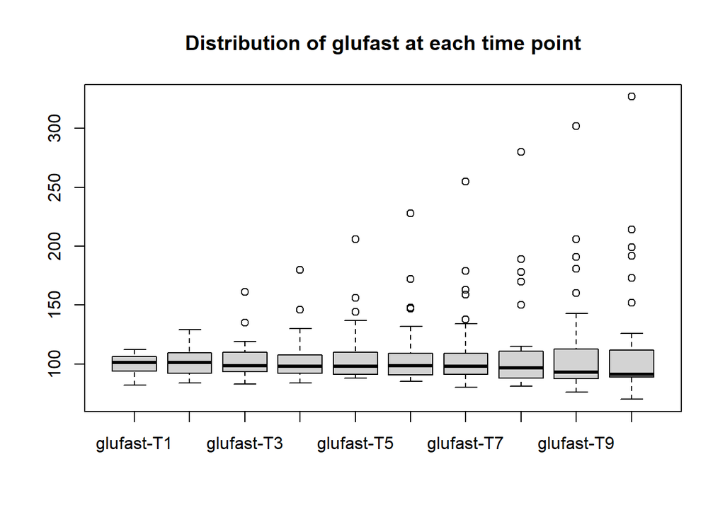

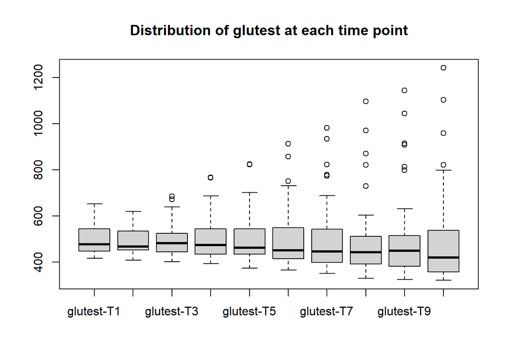

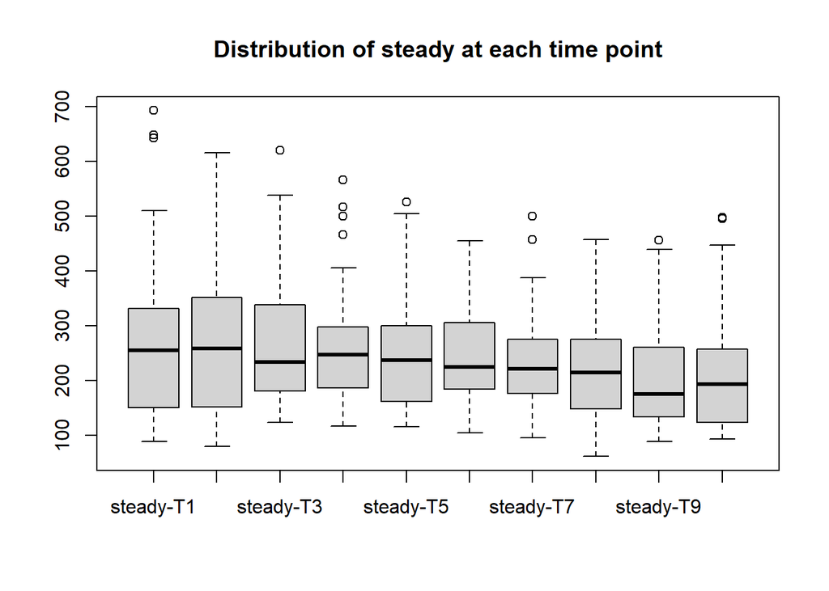

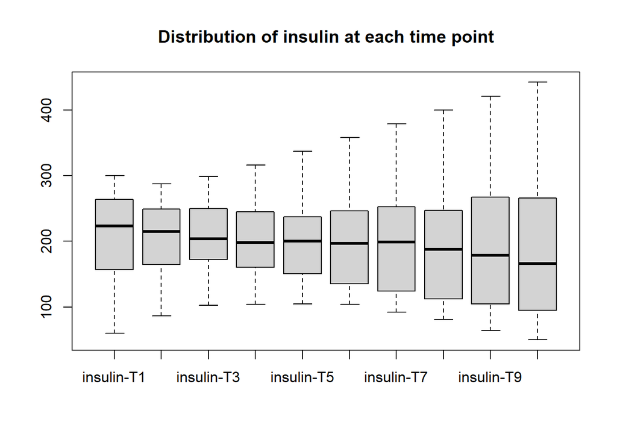

```r
# grab the column names only without the time point.
newname= gsub("[[:punct:]T[:digit:]]","", names(all_diabetes_edited))

# subsetting for measurements variable names onlt
var_names <- newname[6:10]
plot_function <- function(name, data){
  # get the column index of the variables of interest in the data set
  index = grep(name, names(data))
  # subsetting for the interested columns only
  variable <- data[index]
  # create box plots + titme
  boxplot(variable, main = paste("Distribution of",name, "at each time point", sep = " "))

}
# vectorised computation for boxplots using lapply
plots <- lapply(var_names, plot_function, all_diabetes_edited)
```

# Question 5:

*You know you would like to make time series plots of each variable in separate ggplot “facets.” Reshape the data to facilitate this. Include comments to indicate your strategy. Save the reshaped dataframe as a csv file.*

```r
# make the final diabetes data frame into a long format using pivot longer function
all_diabetes_long <- all_diabetes_edited %>% pivot_longer(cols = 6:55, names_to =c("measurement","time"), names_sep = "-")

# check data
head(all_diabetes_long)
```

```
## # A tibble: 6 × 10
##      id takeaways coffeepurch mealprep  wldiet sex   locations measurement time
##   <int>     <int>       <int> <chr>      <int> <chr> <chr>     <chr>       <chr>
## 1    59         1           1 Sometimes      0 M     S         relwt       T1
## 2    59         1           1 Sometimes      0 M     S         glufast     T1
## 3    59         1           1 Sometimes      0 M     S         glutest     T1
## 4    59         1           1 Sometimes      0 M     S         steady      T1
## 5    59         1           1 Sometimes      0 M     S         insulin     T1
## 6    59         1           1 Sometimes      0 M     S         relwt       T2
## # ℹ 1 more variable: value <dbl>
```

```r
# create a new csv file
write.csv(all_diabetes_long, "A4_q5_all_diabetes.csv")
```